# analyze-ab-test-results-notebook-zh-0

## 目录

- 简介
- I - 概率
- II - A/B 测试
- III - 回归

### 大家好，此次我带了一份自己完成的报告，该报告包括模拟零假设抽样建立正态分布、假设性检验验证我的零假设与备择假设、逻辑回归检测变量间的相关性。

### 简介

数学来源于生活，同样也服务于生活，个人非常乐意做到这些用所学的知识服务社会。A/B测试通常是很多领域需要做的，它可以帮我们改善现存的状态，很大程度的帮助公司、机构、政府作出不同的决策。也正因为这样，本人对这个非常的感兴趣

首先，对于这个项目，该项目是电子商务网站运行的 A/B 测试的结果。我的目标是通过这个 notebook 来帮助公司弄清楚他们是否应该使用新的页面，保留旧的页面，或者应该将测试时间延长，之后再做出决定。

```python
import pandas as pd
import numpy as np
import random
import matplotlib.pyplot as plt
%matplotlib inline
#We are setting the seed to assure you get the same answers on quizzes as we set up
random.seed(42)
```

`1.` 现在，导入 `ab_data.csv` 数据

a. 导入数据集查看前几行：

```python
df = pd.read_csv('ab_data.csv')
df.head()
```

|  | user_id | timestamp | group | landing_page | converted |
| --- | --- | --- | --- | --- | --- |
| 0 | 851104 | 2017-01-21 22:11:48.556739 | control | old_page | 0 |
| 1 | 804228 | 2017-01-12 08:01:45.159739 | control | old_page | 0 |
| 2 | 661590 | 2017-01-11 16:55:06.154213 | treatment | new_page | 0 |
| 3 | 853541 | 2017-01-08 18:28:03.143765 | treatment | new_page | 0 |
| 4 | 864975 | 2017-01-21 01:52:26.210827 | control | old_page | 1 |

b. 使用下面的单元格来查找数据集中的行数。

```python
# 原始数据集行数
df.shape[0]
```

```
294478
```

```python
# 独立用户数量
len(df.user_id.unique())
```

```
290584
```

c. 数据集中独立用户的数量。

```python
# 用户转化（付费）的比例
from __future__ import division
len(df.query('converted == 1'))/len(df)
```

```
0.11965919355605512
```

ps: 用户转化与付费的意思一样，用户浏览该网站付费了就相当于转化，同理，未付费就是未转化  
关于`control`与`treatment`----`control`代表对照组，`treatment`代表实验组  
正常来说把`old_page`作为对照组，把`new_page`作为实验组 (请向上看实例数据)

d. 用户转化的比例。

```python
df_new = df.query('landing_page == "new_page"')
df_new.query('group != "treatment"').shape[0]
```

```
1928
```

e. `new_page` 与 `treatment` 不一致的次数。理由：因为我们要让新页面(new_page)对应的全部为测试用户(treatment),所以查看数据集中是否有新页面(new_page)对应的控制用户(control),这些字段的存在会干扰分析结果，所以假如有，删掉它们，结果我需要删掉这1928行

```python
df.info()
```

```
<class 'pandas.core.frame.DataFrame'>
RangeIndex: 294478 entries, 0 to 294477
Data columns (total 5 columns):
user_id         294478 non-null int64
timestamp       294478 non-null object
group           294478 non-null object
landing_page    294478 non-null object
converted       294478 non-null int64
dtypes: int64(2), object(3)
memory usage: 11.2+ MB
```

f. 查看数据集是否存在缺失值，结果无任何的缺失值

`2.`

a. 现在，我将新 dataframe 存储在 **df2** 中。

```python
lists = df_new.query('group != "treatment"').index
df2 = df.drop(lists)
df_b = df.query('landing_page == "old_page"')
lists = df_b.query('group != "control"').index
df2 = df2.drop(lists)
```

现在我第一次清洗了下数据集删除了 treatment 不与 new_page 一致的行或 control 不与 old_page 一致的行

```python
df2.shape[0]
```

```
290585
```

重新查看下行数

```python
# Double Check all of the correct rows were removed - this should be 0
df2[((df2['group'] == 'treatment') == (df2['landing_page'] == 'new_page')) == False].shape[0]
```

```
0
```

检查是否有遗漏

```python
df2.user_id.value_counts().count()
```

```
290584
```

`3.`

a. **df2** 中有290584个唯一的 **user_id**,删掉重复id

```python
df2 = df2[~df2.user_id.duplicated()]
```

c. 删除含有重复的 **user_id** 的行。

## 以上对原始数据的初步清洗基本完成

```python
df2.head(3)
```

|  | user_id | timestamp | group | landing_page | converted |
| --- | --- | --- | --- | --- | --- |
| 0 | 851104 | 2017-01-21 22:11:48.556739 | control | old_page | 0 |
| 1 | 804228 | 2017-01-12 08:01:45.159739 | control | old_page | 0 |
| 2 | 661590 | 2017-01-11 16:55:06.154213 | treatment | new_page | 0 |

放上三行数据便于查找变量

`4.`

a. 不管用户收到什么页面，单个用户的转化率约为 `0.119597`

```python
df2.query('converted == 1').shape[0] / df2.shape[0]
```

```
0.11959708724499628
```

```python
df_control = df2.query('group == "control"')
df_control.query('converted == 1').shape[0] / df2.shape[0]
```

```
0.06018569501417834
```

```python
df_treatment = df2.query('group == "treatment"')
df_treatment.query('converted == 1').shape[0] / df2.shape[0]
```

```
0.05941139223081794
```

### 疑问

d. 因为网站的新旧页面是随机分发给用户的（为模拟真实场景的随机性），那么一个用户收到新页面的概率是多少？

```python
df2.query('landing_page == "new_page"').shape[0] / df2.shape[0]
```

```
0.5000619442226688
```

结果非常接近`50%`，因为有进三十万条的样本量，所以样本采集保证了随机且独立，那我们就可以直观的认为一个用户不论收到新旧页面的先验概率都为`50%`

## 到现在为止，我现在还不能说明究竟是新页面可以让用户更可能的付费，或者是旧页面

## 下面我将开始运用假设性检验来验证新页面是否有效果

`1.` 现在，我需要先做出假设

## 下面我将给出我的原假设与备择假设

>

$H_{0}$: $p_{old}$ = $p_{new}$

$H_{1}$: $p_{old}$ < $p_{new}$

`2.` 假定在零假设中，不管是新页面还是旧页面， $p_{new}$ and $p_{old}$ 都具有等于 **转化** 成功率的“真”成功率，也就是说， $p_{new}$ 与 $p_{old}$ 是相等的。此外，假设它们都等于原数据的转化率，新旧页面都是如此。

我需要执行两次页面之间 **转化** 差异的抽样分布，计算零假设中10000次迭代计算的估计值。

a. 在零假设中，$p_{new}$ 的 **convert rate（转化率）** 为

```python
df2.query('converted == 1').shape[0] / df2.shape[0]
```

```
0.11959708724499628
```

b. 在零假设中， $p_{old}$ 的 **convert rate（转化率）** 为

```python
df2.query('converted == 1').shape[0] / df2.shape[0]
```

```
0.11959708724499628
```

c. $n_{new}$ 为

```python
df2.query('landing_page == "new_page"').shape[0]
```

```
145310
```

d. $n_{old}$为

```python
df2.query('landing_page == "old_page"').shape[0]
```

```
145274
```

e. 在零假设中，使用 $p_{new}$ 转化率模拟 $n_{new}$ 交易，并将这些 $n_{new}$ 1's 与 0's 存储在 **new_page_converted** 中。也就是说对新页面用与原数据相等的转化率（概率），来自动生成 0 和 1 ，0代表未转化，1代表转化

```python
p = df2.query('converted == 1').shape[0] / df2.shape[0]
df2_new = df2.query('landing_page == "new_page"')
new_page_converted = np.random.choice(2,df2_new.shape[0],p=[1-p,p])
new_page_converted
```

```
array([0, 0, 1, ..., 0, 0, 0])
```

f. 在零假设中，使用 $p_{old}$ 转化率模拟 $n_{old}$ 交易，并将这些 $n_{old}$ 1's 与 0's 存储在 **old_page_converted** 中。（同理，这次是对旧页面模拟）

```python
df2_old = df2.query('landing_page == "old_page"')
old_page_converted = np.random.choice(2,df2_old.shape[0],p=[1-p,p])
old_page_converted
```

```
array([0, 0, 0, ..., 0, 0, 0])
```

g. 计算 $p_{new}$ - $p_{old}$ 的模拟值

```python
(new_page_converted == 1).mean() - (old_page_converted == 1).mean()
```

```
-0.0015989220200194193
```

h.下面我将用上面的流程，用同样的p值随机抽样，计算10,000个$p_{new}$ - $p_{old}$ 值，并将这 10,000 个值存储在 **p_diffs**列表中

```python
p_diffs = []
p = df2.query('converted == 1').shape[0]/df2.shape[0]
for i in range(10000):
    new_page_converted = np.random.choice(2,df2_new.shape[0],p=[1-p,p])
    old_page_converted = np.random.choice(2,df2_old.shape[0],p=[1-p,p])
    p_diffs.append((new_page_converted == 1).mean() - (old_page_converted == 1).mean())
```

i. 绘制一个 **p_diffs** 直方图。

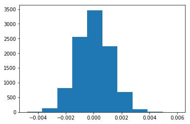

```python
plt.hist(p_diffs);
```

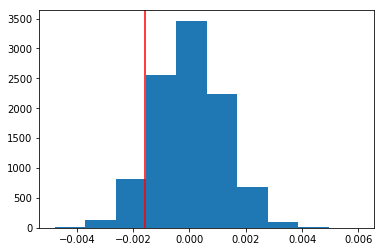

```python
plt.hist(p_diffs)
plt.axvline(df_treatment.query('converted == 1').shape[0]/df_treatment.shape[0]-df_control.query('converted == 1').shape[0]/df_control.shape[0],color='red');
```

```python
vlu = (new_page_converted == 1).mean() - (old_page_converted == 1).mean()
p_diff = np.array(p_diffs)
(p_diff>vlu).mean()
```

```
0.90110000000000001
```

得出的p值为`0.9011`，所以不能拒绝原假设，即 $p_{old}$ = $p_{new}$，所以转化率在新旧页面无差别

l. 我们也可以使用一个内置程序 （built-in）来实现类似的结果。尽管使用内置程序可能更易于编写代码，但上面的内容是对正确思考统计显著性至关重要的思想的一个预排。使用 `n_old` 与 `n_new` 分别引证与旧页面和新页面关联的行数。 下面是计算个页面的转化次数，以及每个页面的访问人数。

```python
df2.head(3)
```

|  | user_id | timestamp | group | landing_page | converted |
| --- | --- | --- | --- | --- | --- |
| 0 | 851104 | 2017-01-21 22:11:48.556739 | control | old_page | 0 |
| 1 | 804228 | 2017-01-12 08:01:45.159739 | control | old_page | 0 |
| 2 | 661590 | 2017-01-11 16:55:06.154213 | treatment | new_page | 0 |

```python
df_old = df2.query('landing_page == "old_page"')
df_new = df2.query('landing_page == "new_page"')
```

```python
import statsmodels.api as sm

convert_old = df_old.query('converted == 1').shape[0]
convert_new = df_new.query('converted == 1').shape[0]
n_old = df_old.shape[0]
n_new = df_new.shape[0]
```

m. 我现在使用 `stats.proportions_ztest` 来计算我的检验统计量与 p-值。

```python
z_score,p_value = sm.stats.proportions_ztest([convert_old,convert_new],[n_old,n_new],alternative='smaller')
```

```python
z_score,p_value
```

```
(1.3109241984234394, 0.90505831275902449)
```

```python
from scipy.stats import norm
norm.cdf(z_score)
norm.ppf(1 - 0.05)
```

```
1.6448536269514722
```

刚刚得出的值为p值，p值是在假定零假设为真的情况下（观察到统计量或支持对则假设更多极端）的概率，p值越大越不能拒绝原假设，p值与错误阈值α通常用来判断是否拒绝原假设选择对则假设，在新旧页面中无区别